# 01 텐서플로우 (Tensorflow)

- 가장 널리 쓰이는 딥러닝 프레임워크 중 하나
- 구글이 주도적으로 개발하는 플랫폼
- 파이썬, C++ API를 기본적으로 제공하고,  
  자바스크립트(JavaScript), 자바(Java), 고(Go), 스위프트(Swift) 등 다양한 프로그래밍 언어를 지원
- tf.keras를 중심으로 고수준 API 통합 (2.x 버전)
- TPU(Tensor Processing Unit) 지원
  - TPU는 GPU보다 전력을 적게 소모, 경제적
  - 일반적으로 32비트(float32)로 수행되는 곱셈 연산을 16비트(float16)로 낮춤

## 텐서플로우 아키텍쳐

[figure not shown]

<sub>출처: https://developers.google.com/machine-learning/crash-course/first-steps-with-tensorflow/toolkit</sub>

## 텐서플로우 시작하기

```python
import numpy as np
import tensorflow as tf
```

```python
print(tf.__version__)
```

```
2.8.0
```

### 텐서(Tensor)의 객체

- 타입(Type): `string`, `float32`, `float16`, `int32`, `int8` 등
- 형상(Shape): 0, 1, 2차원 등의 데이터 차원
- 축(Rank): 차원의 개수

### 텐서의 차원과 연산

```python
a = tf.constant(2) # 상수
print(tf.rank(a)) # rank = 0 (차원이 0)
print(a)
```

```
tf.Tensor(0, shape=(), dtype=int32)
tf.Tensor(2, shape=(), dtype=int32)
```

```python
b = tf.constant([2, 3])
print(tf.rank(b)) # ranke = 1 (차원이 1)
print(b)
```

```
tf.Tensor(1, shape=(), dtype=int32)
tf.Tensor([2 3], shape=(2,), dtype=int32)
```

```python
c = tf.constant([[2, 3], [6, 7]])
print(tf.rank(c)) # rank = 2 (차원이 2)
print(c)
```

```
tf.Tensor(2, shape=(), dtype=int32)
tf.Tensor(
[[2 3]
 [6 7]], shape=(2, 2), dtype=int32)
```

```python
d = tf.constant(["Hello"]) # 문자열
print(tf.rank(d)) # shape = 1 (차원이 1)
print(d)
```

```
tf.Tensor(1, shape=(), dtype=int32)
tf.Tensor([b'Hello'], shape=(1,), dtype=string)
```

### 난수 생성

```python
rand = tf.random.uniform([1], 0, 1) # 0과 1사이 Uniform 분포의 1개의 값
print(rand.shape)
print(rand)
```

```
(1,)
tf.Tensor([0.40860283], shape=(1,), dtype=float32)
```

```python
rand2 = tf.random.normal([1, 2], 0, 1) # 평균이 0, 표준편차가 1인 정규분포에서 1X2차원의 난수 텐서 생성
print(rand2.shape)
print(rand2)
```

```
(1, 2)
tf.Tensor([[ 0.28369257 -0.40319073]], shape=(1, 2), dtype=float32)
```

```python
rand3 = tf.random.normal(shape = (3, 2), mean = 0, stddev = 1)
print(rand3.shape)
print(rand3)
```

```
(3, 2)
tf.Tensor(
[[ 0.70736355 -0.14823559]
 [-0.06171111 -0.49430484]
 [-0.9064844   1.6427883 ]], shape=(3, 2), dtype=float32)
```

### 즉시 실행 모드 (Eager Mode) 지원

- 즉시 실행모드를 통해 텐서플로우를 파이썬처럼 사용할 수 있음
- 1.x 버전에서는 '그래프'를 생성하고, 초기화 한 뒤에 세션을 통해 **값을 흐르게 하는 작업**을 진행해야함

```python
a = tf.constant(3)
a = tf.constant(2)
```

```python
print(tf.add(a, b))
print(a + b)
```

```
tf.Tensor([4 5], shape=(2,), dtype=int32)
tf.Tensor([4 5], shape=(2,), dtype=int32)
```

```python
print(tf.subtract(a, b))
print(a - b)
```

```
tf.Tensor([ 0 -1], shape=(2,), dtype=int32)
tf.Tensor([ 0 -1], shape=(2,), dtype=int32)
```

```python
print(tf.multiply(a, b))
print(a * b)
```

```
tf.Tensor([4 6], shape=(2,), dtype=int32)
tf.Tensor([4 6], shape=(2,), dtype=int32)
```

### 텐서 플로우 ↔ 넘파이

- `numpy()`
- `tf.convet_to_tensor()`

```python
c = tf.add(a, b).numpy()
print(type(c))
print(c)
```

```
<class 'numpy.ndarray'>
[4 5]
```

```python
c_square = np.square(c, dtype = np.float32)
c_tensor = tf.convert_to_tensor(c_square)

print(c_tensor)
print(type(c_tensor))
```

```
tf.Tensor([16. 25.], shape=(2,), dtype=float32)
<class 'tensorflow.python.framework.ops.EagerTensor'>
```

### 넘파이처럼 사용하기

```python
t = tf.constant([[1., 2., 3.], [4., 5., 6.]])

print(t.shape)
print(t.dtype)
```

```
(2, 3)
<dtype: 'float32'>
```

```python
print(t[:, 1:])
```

```
tf.Tensor(
[[2. 3.]
 [5. 6.]], shape=(2, 2), dtype=float32)
```

```python
t[..., 1, tf.newaxis]
```

```
<tf.Tensor: shape=(2, 1), dtype=float32, numpy=
array([[2.],
       [5.]], dtype=float32)>
```

```python
t + 10
```

```
<tf.Tensor: shape=(2, 3), dtype=float32, numpy=
array([[11., 12., 13.],
       [14., 15., 16.]], dtype=float32)>
```

```python
tf.square(t)
```

```
<tf.Tensor: shape=(2, 3), dtype=float32, numpy=
array([[ 1.,  4.,  9.],
       [16., 25., 36.]], dtype=float32)>
```

```python
t @ tf.transpose(t) # 행렬곱
```

```
<tf.Tensor: shape=(2, 2), dtype=float32, numpy=
array([[14., 32.],
       [32., 77.]], dtype=float32)>
```

### 타입 변환

- 텐서의 기본 dtype
  - float형 텐서: `float32`
  - int형 텐서: `int32`
- 연산시 텐서의 타입을 맞춰줘야 함
  - `float32` ~ `float32`
  - `int32` ~ `int32`
  - `flot32` ~ `int32` (x)
- 타입변환에는 `tf.cast()` 사용

```python
a = tf.constant(2)
print(a)

b = tf.constant(2.)
print(b)
# 형태가 다름, 연산을 위해서는 형태를 맞춰야 함
```

```
tf.Tensor(2, shape=(), dtype=int32)
tf.Tensor(2.0, shape=(), dtype=float32)
```

```python
t = tf.constant(30., dtype = tf.float64)
t2 = tf.constant(4.)

print(t2 + tf.cast(t, tf.float32))
```

```
tf.Tensor(34.0, shape=(), dtype=float32)
```

### AutoGraph (오토그래프)

- Tensorflow가 작업을 좀 더 빠르게 동작하게 하기 위한 방법으로 Graph로 만들어 연산을 진행
- `tf.Graph`
- 유연성이 있음
  - 모바일 애플리케이션, 임베디드 기기, 백엔드 서버와 같이 Python 인터프리터가 없는 환경에서 Tensorflow 사용 가능

```python
import timeit
```

### @tf.function

- 자동으로 그래프를 생성(Auto Graph)
- 그래프로 변환하여 사용 -> GPU 연산 가능
- 파이썬으로 구성된 함수를 텐서플로우의 그래프 형태로 다루고 싶을 때 사용가능
- 원본 함수가 필요하다면 `(tf.function).python_function()`

```python
@tf.function
def my_function(x) :
  return x**2 - 10*x + 3

print(my_function(2))
print(my_function(tf.constant(2)))
```

```
tf.Tensor(-13, shape=(), dtype=int32)
tf.Tensor(-13, shape=(), dtype=int32)
```

```python
def my_function_(x):
  return x**2 - 10*x + 3

print(my_function_(2))
print(my_function_(tf.constant(2)))
```

```
-13
tf.Tensor(-13, shape=(), dtype=int32)
```

### 변수 생성

- `tf.Variable`
- 딥러닝 모델 학습 시, 그래프 연산이 필요할 때 사용

```python
X = tf.Variable(20.0)
print(X)
```

```
<tf.Variable 'Variable:0' shape=() dtype=float32, numpy=20.0>
```

### Autograd (자동 미분)

- `tf.GradientTape` API를 사용
- `tf.Variable` 같은 일부 입력에 대한 기울기 계산
  - 기본적으로 한번만 사용됨
- 변수가 포함된 연산만 기록

```python
x = tf.Variable(3.0)

with tf.GradientTape() as tape:
  y = x**2
```

```python
dy_dx = tape.gradient(y, x)
dy_dx.numpy()
```

```
6.0
```

## 간단한 신경망 구조

### 뉴런

- 입력 → 연산 → 활성화함수 → 출력

```python
def sigmoid(x) :
  return (1/ (1 + np.exp(-x)))

def Neuron(x, W, bias = 0) :
  z = x * W + bias
  return sigmoid(x)
```

```python
x = tf.random.normal((1, 2), 0, 1)
W = tf.random.normal((1, 2), 0, 1)

print(x)
print(W)

print(Neuron(x, W))
```

```
tf.Tensor([[-0.5130379  -0.19667345]], shape=(1, 2), dtype=float32)
tf.Tensor([[-1.2702769  0.2979816]], shape=(1, 2), dtype=float32)
[[0.37448168 0.4509895 ]]
```

```python
x = tf.random.normal((1,), 0, 1)
W = tf.random.normal((1, 2), 0, 1)

print(x)
print(W)

print(Neuron(x, W))
```

```
tf.Tensor([0.17041202], shape=(1,), dtype=float32)
tf.Tensor([[ 0.71909696 -1.4329726 ]], shape=(1, 2), dtype=float32)
[0.5425002]
```

### 퍼셉트론 학습 알고리즘 (가중치 업데이트)

## $\qquad w^{(next step)} = w + \eta \ (y - \tilde{y}) \ x$

- $w \ $: 가중치
- $\eta \ $ : 학습률
- $y \ $ : 정답 레이블
- $\tilde{y} \ $: 예측 레이블

```python
x = 1
y = 0
W = tf.random.normal([1], 0, 1)
print(Neuron(x, W))
print('y', y)
```

```
0.7310585786300049
y 0
```

## 시각화 사용

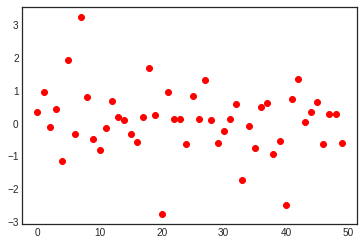

```python
import matplotlib.pyplot as plt
plt.style.use('seaborn-white')

x = range(50)
y = tf.random.normal([50], 0, 1)
plt.plot(x, y, 'ro') # ro : 붉은색 원 / g- : 녹색 선/ b-- : 파란색 점선
plt.show()
```

# 03 케라스(Keras) 기초부터 모델 생성까지

- 파이썬으로 작성된 고수준 신경망 API로 TensorFlow, CNTK, 혹은 Theano와 함께 사용 가능
- 사용자 친화성, 모듈성, 확장성을 통해 빠르고 간편한 프로토타이핑 가능
- 컨볼루션 신경망, 순환 신경망, 그리고 둘의 조합까지 모두 지원
- CPU와 GPU에서 매끄럽게 실행

```python
import tensorflow as tf
from tensorflow import keras
import numpy as np

keras.__version__
```

```
'2.8.0'
```

레이어들을 import하는 방식 (1)

- 일일이 import 하지 않아도 됨
- 코드가 다소 길어질 수 있음

```python
keras.layers.Dense(10, activation = 'sigmoid')
```

```
<keras.layers.core.dense.Dense at 0x7fc5d13fc910>
```

```python
keras.Model()
```

```
<keras.engine.training.Model at 0x7fc5d13a2890>
```

```python
keras.models.Sequential()
```

```
<keras.engine.sequential.Sequential at 0x7fc5d0abad90>
```

레이어들을 import하는 방식 (2)

- 일일이 import 해야함
- 코드가 간결

```python
from tensorflow.keras.layers import Dense, Input, Flatten, Activation
from tensorflow.keras.models import Sequential
from tensorflow.keras import Model
```

```python
Dense(10, activation = 'relu')
```

```
<keras.layers.core.dense.Dense at 0x7fc5d14c61d0>
```

```python
Flatten(input_shape = [28, 28])
```

```
<keras.layers.core.flatten.Flatten at 0x7fc5cc0a1490>
```

```python
X_train = np.random.rand(5500, 2)
Input(shape = X_train.shape[1:])
```

```
<KerasTensor: shape=(None, 2) dtype=float32 (created by layer 'input_1')>
```

## 주요 레이어

### Dense

- Fully-Connected Layer
- 노드수(유닛수), 활성화 함수 등을 지정
- name을 통한 레이어간 구분 가능
- 기본적으로  
  'Glorot_uniform' 가중치, zeros bias로 초기화
  - kernel_initializer 인자를 통해 다른 가중치 초기화를 진행할 수 있음

```python
dense = Dense(10, activation = 'relu', name = 'Dense Layer')
```

```python
dense
```

```
<keras.layers.core.dense.Dense at 0x7fc5cc017110>
```

```python
dense2 = Dense(15, activation = 'softmax')
```

```python
dense2
```

```
<keras.layers.core.dense.Dense at 0x7fc5cc015a50>
```

### Activation

- Dense layer에서 미리 활성화함수를 지정할 수도 있지만 때에 따라서 따로 레이어를 만들어줄 수 있음

```python
dense = Dense(10, kernel_initializer = 'he_normal', name = 'Dense Layer')
dense = Activation(dense)
dense
```

```
<keras.layers.core.activation.Activation at 0x7fc5cc01bb90>
```

### Flatten

- 배치 크기(또는 데이터 크기)를 제외하고 데이터를 1차원으로 쭉 펼치는 작업
- 예시)

  ```
    (128, 3, 2, 2) ---> (128, 12)
  ```

```python
Flatten(input_shape = (28, 28))
```

```
<keras.layers.core.flatten.Flatten at 0x7fc5cc0175d0>
```

### Input

```python
Input_1 = Input(shape = (28, 28), dtype = tf.float32)
Input_2 = Input(shape = (8,), dtype = tf.int32)
```

```python
Input_1, Input_2
```

```
(<KerasTensor: shape=(None, 28, 28) dtype=float32 (created by layer 'input_4')>,
 <KerasTensor: shape=(None, 8) dtype=int32 (created by layer 'input_5')>)
```

## 모델 구성 방법

- Sequential()
- 서브클래싱(Subclassing)
- 함수형 API

### Sequential()

- 모델이 순차적으로 진행할 때 사용
- 간단한 방법
  - Sequential 객체 생성 후, **add**를 통한 방법
  - Sequential 인자에 한번에 추가
- 다중 입력 및 출력이 존재하는 등의 복잡한 모델을 구성할 수 없음

```python
from tensorflow.keras.layers import Dense, Input, Flatten, Activation
from tensorflow.keras.models import Sequential, Model
from tensorflow.keras.utils import plot_model
```

```python
# 층을 하나씩 추가
model = Sequential()
model.add(Input(shape = (28, 28)))
model.add(Dense(300, activation = 'relu'))
model.add(Dense(100, activation = 'relu'))
model.add(Dense(10, activation = 'softmax'))
```

모델 구조 확인

- model 객체의 **summary()** 이용

```python
model.summary()
```

```
Model: "sequential_1"
_________________________________________________________________
 Layer (type)                Output Shape              Param #
=================================================================
 dense_3 (Dense)             (None, 28, 300)           8700

 dense_4 (Dense)             (None, 28, 100)           30100

 dense_5 (Dense)             (None, 28, 10)            1010

=================================================================
Total params: 39,810
Trainable params: 39,810
Non-trainable params: 0
_________________________________________________________________
```

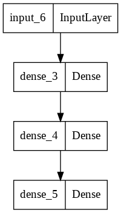

```python
plot_model(model) # 모델 시각화
```

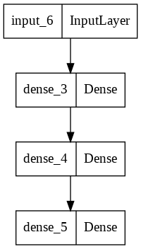

```python
plot_model(model, to_file = 'model1.png') # 모델 시각화 저장
```

```python
# 층을 한번에 추가
model = Sequential([Input(shape = (28, 28), name = "Input"),
                   Dense(300, activation = 'relu', name = 'Dense1'),
                   Dense(100, activation = 'relu', name = 'Dense2'),
                   Dense(10, activation = 'softmax', name = 'Output')])
```

```python
model.summary()
```

```
Model: "sequential_2"
_________________________________________________________________
 Layer (type)                Output Shape              Param #
=================================================================
 Dense1 (Dense)              (None, 28, 300)           8700

 Dense2 (Dense)              (None, 28, 100)           30100

 Output (Dense)              (None, 28, 10)            1010

=================================================================
Total params: 39,810
Trainable params: 39,810
Non-trainable params: 0
_________________________________________________________________
```

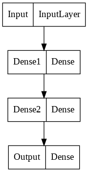

```python
plot_model(model)
```

### 함수형 API

- 가장 권장되는 방법
- 모델을 복잡하고, 유연하게 구성 가능
- 다중 입출력을 다룰 수 있음

```python
from tensorflow.keras.models import Model
from tensorflow.keras.layers import Input, Flatten, Dense
from tensorflow.keras.utils import plot_model
```

```python
inputs = Input(shape = (28, 28, 1))

x = Flatten(input_shape = (28, 28, 1))(inputs)
x = Dense(300, activation = 'relu')(x)
x = Dense(100, activation = 'relu')(x)
x = Dense(10, activation = 'softmax')(x)
```

```python
model = Model(inputs = inputs, outputs = x)
```

```python
model.summary()
```

```
Model: "model_2"
_________________________________________________________________
 Layer (type)                Output Shape              Param #
=================================================================
 input_10 (InputLayer)       [(None, 28, 28, 1)]       0

 flatten_5 (Flatten)         (None, 784)               0

 dense_9 (Dense)             (None, 300)               235500

 dense_10 (Dense)            (None, 100)               30100

 dense_11 (Dense)            (None, 10)                1010

=================================================================
Total params: 266,610
Trainable params: 266,610
Non-trainable params: 0
_________________________________________________________________
```

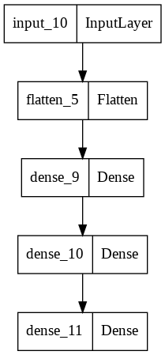

```python
plot_model(model)
```

## concatenate 다중입력

```python
from tensorflow.keras.layers import Concatenate

input_layer = Input(shape = (28, 28))
hidden1 = Dense(100, activation = 'relu')(input_layer)
hidden2 = Dense(30, activation = 'relu')(hidden1)
concat = Concatenate()([input_layer, hidden2])
output = Dense(1)(concat)

model = Model(inputs = [input_layer], outputs = [output])
```

```python
model.summary()
```

```
Model: "model_3"
__________________________________________________________________________________________________
 Layer (type)                   Output Shape         Param #     Connected to
==================================================================================================
 input_12 (InputLayer)          [(None, 28, 28)]     0           []

 dense_15 (Dense)               (None, 28, 100)      2900        ['input_12[0][0]']

 dense_16 (Dense)               (None, 28, 30)       3030        ['dense_15[0][0]']

 concatenate_1 (Concatenate)    (None, 28, 58)       0           ['input_12[0][0]',
                                                                  'dense_16[0][0]']

 dense_17 (Dense)               (None, 28, 1)        59          ['concatenate_1[0][0]']

==================================================================================================
Total params: 5,989
Trainable params: 5,989
Non-trainable params: 0
__________________________________________________________________________________________________
```

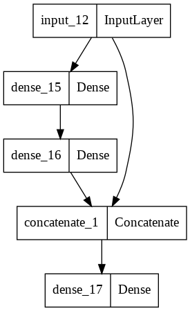

```python
plot_model(model)
```

```python
input_1 = Input(shape = (10, 10), name = 'input_1')
input_2 = Input(shape = (10, 28), name = 'input_2')

hidden1 = Dense(100, activation = 'relu')(input_2)
hidden2 = Dense(10, activation = 'relu')(hidden1)
concat = Concatenate()([input_1, hidden2])
output = Dense(1, activation = 'sigmoid', name = 'output')(concat)

model = Model(inputs = [input_1, input_2], outputs = [output])
```

```python
model.summary()
```

```
Model: "model_4"
__________________________________________________________________________________________________
 Layer (type)                   Output Shape         Param #     Connected to
==================================================================================================
 input_2 (InputLayer)           [(None, 10, 28)]     0           []

 dense_20 (Dense)               (None, 10, 100)      2900        ['input_2[0][0]']

 input_1 (InputLayer)           [(None, 10, 10)]     0           []

 dense_21 (Dense)               (None, 10, 10)       1010        ['dense_20[0][0]']

 concatenate_3 (Concatenate)    (None, 10, 20)       0           ['input_1[0][0]',
                                                                  'dense_21[0][0]']

 output (Dense)                 (None, 10, 1)        21          ['concatenate_3[0][0]']

==================================================================================================
Total params: 3,931
Trainable params: 3,931
Non-trainable params: 0
__________________________________________________________________________________________________
```

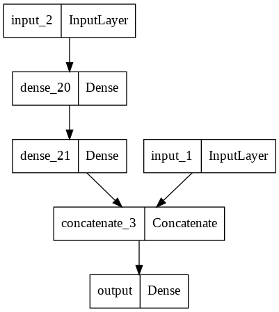

```python
plot_model(model)
```

```python
input_ = Input(shape = (10, 10), name = 'input_')

hidden1 = Dense(100, activation = 'relu')(input_)
hidden2 = Dense(10, activation = 'relu')(hidden1)

output = Dense(1, activation = 'sigmoid', name = 'main_output')(hidden2)
sub_out = Dense(1, name = 'sum_output')(hidden2)

model = Model(inputs = [input_], outputs = [output, sub_out])
```

```python
model.summary()
```

```
Model: "model_5"
__________________________________________________________________________________________________
 Layer (type)                   Output Shape         Param #     Connected to
==================================================================================================
 input_ (InputLayer)            [(None, 10, 10)]     0           []

 dense_22 (Dense)               (None, 10, 100)      1100        ['input_[0][0]']

 dense_23 (Dense)               (None, 10, 10)       1010        ['dense_22[0][0]']

 main_output (Dense)            (None, 10, 1)        11          ['dense_23[0][0]']

 sum_output (Dense)             (None, 10, 1)        11          ['dense_23[0][0]']

==================================================================================================
Total params: 2,132
Trainable params: 2,132
Non-trainable params: 0
__________________________________________________________________________________________________
```

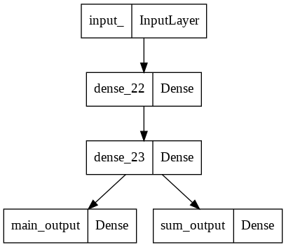

```python
plot_model(model)
```

```python
input_1 = Input(shape = (10, 10), name = 'input_1')
input_2 = Input(shape = (10, 20), name = 'input_2')

hidden1 = Dense(100, activation = 'relu')(input_2)
hidden2 = Dense(10, activation = 'relu')(hidden1)
concat = Concatenate()([input_1, hidden2])
output = Dense(1, activation = 'sigmoid', name = 'main_output')(concat)
sub_out = Dense(1, name = 'sum_output')(hidden2)

model = Model(inputs = [input_1, input_2], outputs = [output, sub_out])
```

```python
model.summary()
```

```
Model: "model_6"
__________________________________________________________________________________________________
 Layer (type)                   Output Shape         Param #     Connected to
==================================================================================================
 input_2 (InputLayer)           [(None, 10, 20)]     0           []

 dense_28 (Dense)               (None, 10, 100)      2100        ['input_2[0][0]']

 input_1 (InputLayer)           [(None, 10, 10)]     0           []

 dense_29 (Dense)               (None, 10, 10)       1010        ['dense_28[0][0]']

 concatenate_5 (Concatenate)    (None, 10, 20)       0           ['input_1[0][0]',
                                                                  'dense_29[0][0]']

 main_output (Dense)            (None, 10, 1)        21          ['concatenate_5[0][0]']

 sum_output (Dense)             (None, 10, 1)        11          ['dense_29[0][0]']

==================================================================================================
Total params: 3,142
Trainable params: 3,142
Non-trainable params: 0
__________________________________________________________________________________________________
```

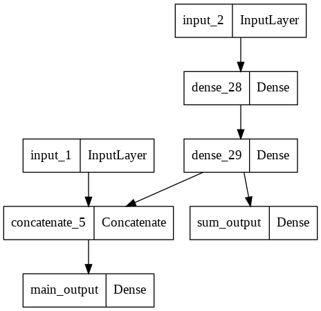

```python
plot_model(model)
```

### 서브클래싱(Subclassing)

- 커스터마이징에 최적화된 방법
- Model 클래스를 상속받아 Model이 포함하는 기능을 사용할 수 있음
  - `fit()`, `evaluate()`, `predict()`
  - `save()`, `load()`
- 주로 `call()` 메소드안에서 원하는 계산 가능
  - for, if, 저수준 연산 등
- 권장되는 방법은 아니지만 어떤 모델의 구현 코드를 참고할 때  
  해석할 수 있어야함

```python
from tensorflow.keras.models import Model
from tensorflow.keras.layers import Input, Flatten, Dense
from tensorflow.keras.utils import plot_model
```

```python
class MyModel(Model) :
  def __init__(self, units = 30, activation = 'relu', **kwargs):
    super(MyModel, self).__init__(**kwargs)

    self.dense_layer1 = Dense(300, activation = activation)
    self.dense_layer2 = Dense(100, activation = activation)
    self.dense_layer3 = Dense(units, activation = activation)

    self.output_layer = Dense(10, activation = 'softmax')

  def call(self, inputs):
    x = self.dense_layer1(Inputs)
    x = self.dense_layer2(x)
    x = self.dense_layer3(x)
    x = self.output_layer(x)
    return x
```

## 모델 가중치 확인

```python
from tensorflow.keras.models import Model
from tensorflow.keras.layers import Input, Flatten, Dense
from tensorflow.keras.utils import plot_model
```

```python
input = Input(shape = (28, 28, 1))

x = Flatten(input_shape = (28, 28, 1))(inputs)
x = Dense(300, activation = 'relu')(x)
x = Dense(100, activation = 'relu')(x)
x = Dense(10, activation = 'softmax')(x)

model = Model(inputs = inputs, outputs = x)
```

```python
model.summary()
```

```
Model: "model_7"
_________________________________________________________________
 Layer (type)                Output Shape              Param #
=================================================================
 input_10 (InputLayer)       [(None, 28, 28, 1)]       0

 flatten_6 (Flatten)         (None, 784)               0

 dense_30 (Dense)            (None, 300)               235500

 dense_31 (Dense)            (None, 100)               30100

 dense_32 (Dense)            (None, 10)                1010

=================================================================
Total params: 266,610
Trainable params: 266,610
Non-trainable params: 0
_________________________________________________________________
```

모델의 레이어들이 리스트로 표현됨

```python
model.layers
```

```
[<keras.engine.input_layer.InputLayer at 0x7fc5cbe20190>,
 <keras.layers.core.flatten.Flatten at 0x7fc5cb777290>,
 <keras.layers.core.dense.Dense at 0x7fc5cb6a1950>,
 <keras.layers.core.dense.Dense at 0x7fc5cb5aae50>,
 <keras.layers.core.dense.Dense at 0x7fc5cb518390>]
```

```python
hidden_2 = model.layers[2]
hidden_2.name
```

```
'dense_30'
```

위의 layer name 참고

```python
model.get_layer('dense_30') is hidden_2
```

```
True
```

```python
weights, biases = hidden_2.get_weights()
```

```python
weights, biases
```

```
(array([[-0.03255778, -0.03687011,  0.05811143, ...,  0.05807719,
         -0.02922599,  0.0042151 ],
        [-0.04842991, -0.00289991, -0.03973352, ..., -0.00622535,
         -0.01195453, -0.00842583],
        [-0.01055273, -0.0002572 ,  0.05353135, ...,  0.04163312,
          0.03901501,  0.00441254],
        ...,
        [ 0.02550796,  0.03237279, -0.00393106, ..., -0.01816456,
          0.06101705, -0.04656857],
        [-0.04336336, -0.05527383, -0.03025762, ...,  0.07010521,
          0.02544177,  0.03163753],
        [ 0.01564383,  0.06511627,  0.03540467, ..., -0.03218127,
          0.02961003,  0.02346466]], dtype=float32),
 array([0., 0., 0., 0., 0., 0., 0., 0., 0., 0., 0., 0., 0., 0., 0., 0., 0.,
        0., 0., 0., 0., 0., 0., 0., 0., 0., 0., 0., 0., 0., 0., 0., 0., 0.,
        0., 0., 0., 0., 0., 0., 0., 0., 0., 0., 0., 0., 0., 0., 0., 0., 0.,
        0., 0., 0., 0., 0., 0., 0., 0., 0., 0., 0., 0., 0., 0., 0., 0., 0.,
        0., 0., 0., 0., 0., 0., 0., 0., 0., 0., 0., 0., 0., 0., 0., 0., 0.,
        0., 0., 0., 0., 0., 0., 0., 0., 0., 0., 0., 0., 0., 0., 0., 0., 0.,
        0., 0., 0., 0., 0., 0., 0., 0., 0., 0., 0., 0., 0., 0., 0., 0., 0.,
        0., 0., 0., 0., 0., 0., 0., 0., 0., 0., 0., 0., 0., 0., 0., 0., 0.,
        0., 0., 0., 0., 0., 0., 0., 0., 0., 0., 0., 0., 0., 0., 0., 0., 0.,
        0., 0., 0., 0., 0., 0., 0., 0., 0., 0., 0., 0., 0., 0., 0., 0., 0.,
        0., 0., 0., 0., 0., 0., 0., 0., 0., 0., 0., 0., 0., 0., 0., 0., 0.,
        0., 0., 0., 0., 0., 0., 0., 0., 0., 0., 0., 0., 0., 0., 0., 0., 0.,
        0., 0., 0., 0., 0., 0., 0., 0., 0., 0., 0., 0., 0., 0., 0., 0., 0.,
        0., 0., 0., 0., 0., 0., 0., 0., 0., 0., 0., 0., 0., 0., 0., 0., 0.,
        0., 0., 0., 0., 0., 0., 0., 0., 0., 0., 0., 0., 0., 0., 0., 0., 0.,
        0., 0., 0., 0., 0., 0., 0., 0., 0., 0., 0., 0., 0., 0., 0., 0., 0.,
        0., 0., 0., 0., 0., 0., 0., 0., 0., 0., 0., 0., 0., 0., 0., 0., 0.,
        0., 0., 0., 0., 0., 0., 0., 0., 0., 0., 0.], dtype=float32))
```

```python
print(weights.shape)
print(biases.shape)
```

```
(784, 300)
(300,)
```

## 모델 컴파일(compile)

- 모델을 구성한 후, 사용할 손실함수(loss), 옵티마이저(optimizer)를 지정

```python
model.compile(loss = 'sparse_categorical_crossentropy',
              optimizer = 'sgd',
              metrics = ['accuracy'])
```

### 참고1

#### loss

- `keras.losses.sparse_categorical_crossentropy` 등과 같이 지정 가능
  - `sparse_categorical_crossentropy`  
    클래스가 배타적, 즉 MNIST 예제에서 (0, 1, 2, ..., 9)와 같은 방식으로 구분되어 있을 때 사용
  - `categorical_crossentropy` 클래스가 원-핫 인코딩 방식으로 되어 있을 때 사용
  - `binary_crossentropy` 이진 분류를 수행할 때 사용
  - `mean_square_error` 회귀

#### optimizer

- https://ganghee-lee.tistory.com/24
- `keras.optimizer.SGD()` 등과 같이 사용 가능
  - 보통 옵티마이저의 튜닝을 위해 따로 객체를 생성하여 컴파일

    ```
    optimizer = keras.optimizer.SGD(learning_rate=1e-5)
    model.compile(...,
                  optimizer=optimzer,
                  ...)
    ```

- `keras.optimizer.Adam()` 도 많이 사용

#### metrics

- 모니터링할 지표
- 주로 'accuracy', 'acc'로도 가능

### 참고2 - 컴파일 설정 예시

- 평균 제곱 오차 회귀 문제

  ```
  model.compile(loss = 'mse',
                optimizer = RMSprop(),
                metrics=['mae'])
  ```

- 이진 분류

  ```
  model.compile(loss = 'binary_crossentropy',
                optimizer = RMSprop(),
                metrics=['accuracy'])
  ```

- 다항 분류

  ```
  model.compile(loss = 'categorical_crossentropy',
                optimizer = RMSprop(),
                metrics=['accuracy'])
  ```

## 모델 훈련, 평가 및 예측

- `fit()` 함수
  - train_data(학습 데이터), train_label(데이터의 정답)
  - epochs
  - batch_size

batch_size(배치사이즈)  
배치사이즈는 몇 개의 관측치에 대한 예측을 하고, 레이블 값과 비교를 하는지를 설정하는 파라미터입니다. 100개의 데이터에서 배치사이즈가 100이면 전체 데이터에 대해 모두 예측한 뒤 실제 레이블 값과 비교한 후 가중치 갱신을 합니다. 배치사이즈가 10이면 10개 데이터에 대해 예측한 뒤 실제 레이블 값과 비교하며 가중치 갱신도 10번 발생합니다.

배치사이즈가 100인 경우, 어떤 한 유형에 대한 예측이 틀리면 이후 비슷한 유형에 대한 예측도 틀릴 수 있습니다. 하지만 배치사이즈가 10인 경우에는, 데이터 10개마다 실제 레이블 값과 비교하기 때문에, 처음에 틀리게 예측하더라도 가중치 업데이트를 하면서 뒤에는 맞추게 될 확률이 높습니다.

배치사이즈가 클수록 많은 데이터를 저장해두어야 하므로 용량이 커야합니다. 반면, 배치사이즈가 작으면 학습은 촘촘하게 되겠지만 계속 레이블과 비교하고, 가중치를 업데이트하는 과정을 거치면서 시간이 오래 걸립니다.

- validation_data
- `evaluate()` 함수
  - 테스트 데이터
- `predict()` 임의의 데이터를 인자로 넣어 예측 가능

## MNIST 예제를 통해 모델 구성하기

- keras.datasets 에 포함되어 있는 데이터셋

[figure not shown]

  <sub>출처: https://www.tensorflow.org/datasets/catalog/mnist</sub>

### modules import

```python
import tensorflow as tf
from tensorflow.keras.datasets.mnist import load_data
from tensorflow.keras.models import Sequential
from tensorflow.keras import models
from tensorflow.keras.layers import Dense, Input, Flatten
from tensorflow.keras.utils import to_categorical
from tensorflow.keras.utils import plot_model

from sklearn.model_selection import train_test_split
import numpy as np
import matplotlib.pyplot as plt
plt.style.use('seaborn-white')
```

### 데이터셋 로드

- MNIST 데이터셋을 로드
- Train Data 중, 30%를 검증 데이터(validation data)로 사용

```python
tf.random.set_seed(111)

(x_train_full, y_train_full), (x_test, y_test) = load_data(path = 'mnist.npz')

x_train, x_val, y_train, y_val = train_test_split(x_train_full, y_train_full,
                                                  test_size = 0.3,
                                                  random_state = 111)
```

```
Downloading data from https://storage.googleapis.com/tensorflow/tf-keras-datasets/mnist.npz
```

### 데이터 확인

```python
x_train.shape, x_val.shape, x_test.shape
```

```
((42000, 28, 28), (18000, 28, 28), (10000, 28, 28))
```

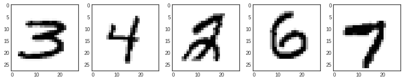

```python
num_sample = 5

random_idxs = np.random.randint(60000, size = num_sample)

plt.figure(figsize = (14, 8))
for i, idx in enumerate(random_idxs):
  img = x_train_full[idx, :]
  label = y_train_full[idx]

  plt.subplot(1, len(random_idxs), i+1)
  plt.imshow(img)
```

```python
y_train[0] # 원핫 인코딩 => loss : categorical_crossentropy
```

[output not shown]

### 데이터 전처리

- Normalization

```python
x_train = x_train / 255
x_val = x_val / 255
x_test = x_test / 255
```

```python
y_train = to_categorical(y_train)
y_val = to_categorical(y_val)
y_test = to_categorical(y_test)
```

### 모델 구성 (Sequential)

```python
model = Sequential([Input(shape = (28, 28), name = 'input'),
                  Flatten(input_shape = [28, 28], name = 'flatten'),
                  Dense(100, activation = 'relu', name = 'dense1'),
                  Dense(64, activation = 'relu', name = 'dense2'),
                  Dense(32, activation = 'relu', name = 'dense3'),
                  Dense(10, activation = 'softmax', name = 'output')])
```

```python
model.summary()
```

```
Model: "sequential_3"
_________________________________________________________________
 Layer (type)                Output Shape              Param #
=================================================================
 flatten (Flatten)           (None, 784)               0

 dense1 (Dense)              (None, 100)               78500

 dense2 (Dense)              (None, 64)                6464

 dense3 (Dense)              (None, 32)                2080

 output (Dense)              (None, 10)                330

=================================================================
Total params: 87,374
Trainable params: 87,374
Non-trainable params: 0
_________________________________________________________________
```

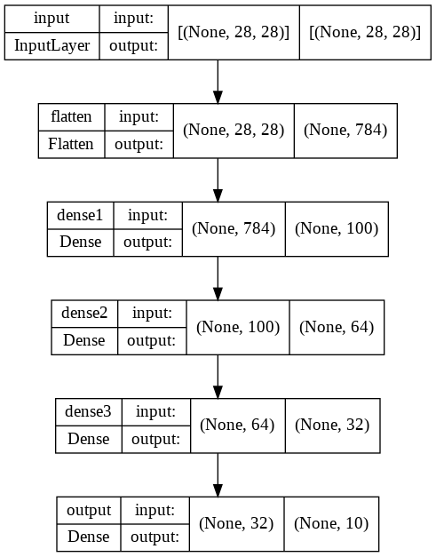

```python
plot_model(model, show_shapes = True)
```

### 모델 컴파일

```python
model.compile(loss = 'categorical_crossentropy',
              optimizer = 'sgd',
              metrics = ['accuracy'])
```

### 모델 학습

- 모델 시각화를 위해 history라는 변수에 학습 과정을 담음

```python
history = model.fit(x_train, y_train,
                    epochs = 50,
                    batch_size = 128,
                    validation_data = (x_val, y_val),
                    verbose = False)
```

### 학습 결과 시각화

```python
history.history.keys()
```

```
dict_keys(['loss', 'accuracy', 'val_loss', 'val_accuracy'])
```

[figure not shown]

```python
history_dict = history.history

loss = history_dict['loss']
val_loss = history_dict['val_loss']

confusion
```

### 모델 평가 (1)

- evaluate()

```python
model.evaluate(x_test, y_test)
```

```
[0.10700495541095734, 0.9685999751091003]
```

### 학습된 모델을 통해 값 예측

```python
pred_ys = model.predict(x_test)
print(pred_ys.shape)

np.set_printoptions(precision = 7)
print(pred_ys[0]) # 각 범주에 속할 확률
```

```
(10000, 10)
[7.8776274e-09 4.2801331e-09 3.0606387e-07 1.7002998e-05 4.9110962e-11
 3.1860882e-08 3.9978023e-13 9.9998248e-01 1.9759263e-08 1.3697648e-07]
```

```
(array([7]),)
```

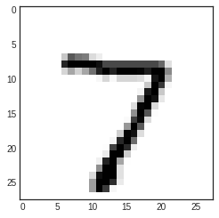

```python
arg_pred_y = np.argmax(pred_ys, axis = 1)

plt.imshow(x_test[0])
np.where(y_test[0] == np.max(y_test[0]))
```

### 모델 평가 (2)

- 혼동행렬 (Confusion Maxtrix)

```python
from sklearn.metrics import confusion_matrix
import seaborn as sns
sns.set(style = 'white')
```

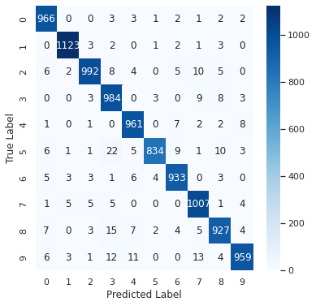

```python
plt.figure(figsize = (6, 6))
cm = confusion_matrix(np.argmax(y_test, axis = -1), np.argmax(pred_ys, axis = -1))
sns.heatmap(cm, annot = True, fmt = 'd', cmap = 'Blues')
plt.xlabel('Predicted Label')
plt.ylabel('True Label')
plt.show()
```

### 모델 평가 (3)

- 분류 보고서

```python
from sklearn.metrics import classification_report

print(classification_report(np.argmax(y_test, axis = -1), np.argmax(pred_ys, axis = -1)))
```

```
              precision    recall  f1-score   support

           0       0.97      0.99      0.98       980
           1       0.99      0.99      0.99      1135
           2       0.98      0.96      0.97      1032
           3       0.94      0.97      0.95      1010
           4       0.96      0.98      0.97       982
           5       0.99      0.93      0.96       892
           6       0.97      0.97      0.97       958
           7       0.96      0.98      0.97      1028
           8       0.96      0.95      0.96       974
           9       0.98      0.95      0.96      1009

    accuracy                           0.97     10000
   macro avg       0.97      0.97      0.97     10000
weighted avg       0.97      0.97      0.97     10000
```

## 모델 저장과 복원

- `save()`
- `load_model()`
- (주의)  
  시퀀셜 API, 함수형 API에서는 **모델**의 저장 및 로드기 가능하지만 서브클래싱 방식으로는 할 수 없음

  서브클래싱 방식

  ```
  save_weights()
  load_weights()
  ```

  위 두가지를 통해 **모델의 파라미터**만 저장 및 로드
- JSON 형식
  - `model.to_json()` (저장)
  - `tf.keras.models.model_from_json(file_path)` (복원)
- YAML로 직렬화
  - `model.to_yaml()` (저장)
  - `tf.keras.models.model_from_yaml(file_path)` (복원)

```python
model.save('mnist_model.h5')
```

```python
loaded_model = models.load_model('mnist_model.h5')
```

```python
loaded_model.summary()
```

```
Model: "sequential_3"
_________________________________________________________________
 Layer (type)                Output Shape              Param #
=================================================================
 flatten (Flatten)           (None, 784)               0

 dense1 (Dense)              (None, 100)               78500

 dense2 (Dense)              (None, 64)                6464

 dense3 (Dense)              (None, 32)                2080

 output (Dense)              (None, 10)                330

=================================================================
Total params: 87,374
Trainable params: 87,374
Non-trainable params: 0
_________________________________________________________________
```

## 콜백 (Callbacks)

- `fit()` 함수의 callbacks 매개변수를 사용하여 케라스가 훈련의 시작이나 끝에 호출할 객체 리스트를 지정할 수 있음
- 여러 개 사용 가능
- ModelCheckpoint
  - `tf.keras.callbacks.ModelCheckpoint`
  - 정기적으로 모델의 체크포인트를 저장하고, 문제가 발생할 때 복구하는데 사용
- EarlyStopping
  - `tf.keras.callbacks.EarlyStopping`
  - 검증 성능이 한동안 개선되지 않을 경우 학습을 중단할 때 사용
- LearningRateSchduler
  - `tf.keras.callbacks.LearningRateSchduler`
  - 최적화를 하는 동안 학습률(learning_rate)를 동적으로 변경할 때 사용
- TensorBoard
  - `tf.keras.callbacks.TensorBoard`
  - 모델의 경과를 모니터링할 때 사용

```python
tf.random.set_seed(111)

(x_train_full, y_train_full), (x_test, y_test) = load_data(path = 'mnist.npz')

x_train, x_val, y_train, y_val = train_test_split(x_train_full, y_train_full,
                                                  test_size = 0.3,
                                                  random_state = 111)
```

```python
x_train = x_train / 255
x_val = x_val / 255
x_test = x_test / 255
```

```python
y_train = to_categorical(y_train)
y_val = to_categorical(y_val)
y_test = to_categorical(y_test)
```

```python
def build_model():
  model = Sequential([Input(shape = (28, 28), name = 'input'),
                  Flatten(input_shape = [28, 28], name = 'flatten'),
                  Dense(100, activation = 'relu', name = 'dense1'),
                  Dense(64, activation = 'relu', name = 'dense2'),
                  Dense(32, activation = 'relu', name = 'dense3'),
                  Dense(10, activation = 'softmax', name = 'output')])

  model.compile(loss = 'categorical_crossentropy',
              optimizer = 'sgd',
              metrics = ['accuracy'])

  return model

model = build_model()

model.summary()
```

```
Model: "sequential_4"
_________________________________________________________________
 Layer (type)                Output Shape              Param #
=================================================================
 flatten (Flatten)           (None, 784)               0

 dense1 (Dense)              (None, 100)               78500

 dense2 (Dense)              (None, 64)                6464

 dense3 (Dense)              (None, 32)                2080

 output (Dense)              (None, 10)                330

=================================================================
Total params: 87,374
Trainable params: 87,374
Non-trainable params: 0
_________________________________________________________________
```

```python
from tensorflow.keras.models import load_model
from tensorflow.keras.callbacks import ModelCheckpoint, EarlyStopping, LearningRateScheduler, TensorBoard
```

### ModelCheckpoint

```python
check_point_cb = ModelCheckpoint('keras_mnist_model.h5')
history = model.fit(x_train, y_train, epochs = 10, callbacks = [check_point_cb], verbose = False)
```

```python
history.history.keys()
```

```
dict_keys(['loss', 'accuracy'])
```

```python
loaded_model = load_model('keras_mnist_model.h5')
loaded_model.summary()
```

```
Model: "sequential_4"
_________________________________________________________________
 Layer (type)                Output Shape              Param #
=================================================================
 flatten (Flatten)           (None, 784)               0

 dense1 (Dense)              (None, 100)               78500

 dense2 (Dense)              (None, 64)                6464

 dense3 (Dense)              (None, 32)                2080

 output (Dense)              (None, 10)                330

=================================================================
Total params: 87,374
Trainable params: 87,374
Non-trainable params: 0
_________________________________________________________________
```

최상의 모델만을 저장

- save_best_only=True

```python
model = build_model()

cp = ModelCheckpoint('keras_best_model.h5', save_best_only = True)

history = model.fit(x_train, y_train, epochs = 10,
                    validation_data = (x_val, y_val), callbacks = [cp], verbose = False)
```

```python
history.history.keys(), history.history['loss']
```

```
(dict_keys(['loss', 'accuracy', 'val_loss', 'val_accuracy']),
 [0.8839646577835083,
  0.32776856422424316,
  0.26329630613327026,
  0.22268429398536682,
  0.1947205811738968,
  0.1729980707168579,
  0.1557256579399109,
  0.14114493131637573,
  0.12922975420951843,
  0.11837994307279587])
```

```python
loaded_model2 = load_model('keras_best_model.h5')
loaded_model2.summary()
```

```
Model: "sequential_6"
_________________________________________________________________
 Layer (type)                Output Shape              Param #
=================================================================
 flatten (Flatten)           (None, 784)               0

 dense1 (Dense)              (None, 100)               78500

 dense2 (Dense)              (None, 64)                6464

 dense3 (Dense)              (None, 32)                2080

 output (Dense)              (None, 10)                330

=================================================================
Total params: 87,374
Trainable params: 87,374
Non-trainable params: 0
_________________________________________________________________
```

### EarlyStopping

- 일정 에포크(patience) 동안 검증 세트에 대한 점수가 오르지 않으면 학습을 멈춤
- 모델이 향상되지 않으면 학습이 자동으로 중지되므로,  
  에포크(epochs) 숫자를 크게 해도 무방
- 학습이 끝난 후의 최상의 가중치를 복원하기 때문에 모델을 따로 복원할 필요없음

```python
model = build_model()

cb = ModelCheckpoint('keras_best_model2.h5', save_best_only= True)
early_stopping_cb = EarlyStopping(patience = 3, monitor = 'val_loss',
                                  restore_best_weights = True)

history = model.fit(x_train, y_train, epochs = 50, verbose = False,
                    validation_data = (x_val, y_val), callbacks = [cp, early_stopping_cb])
```

### LearningRateScheduler

```python
def scheduler(epoch, Learning_rate) :
  if epoch < 10 :
    return learning_rate
  else :
    return learning_rate * tf.math.exp(-0.1)
```

```python
model = build_model()

round(model.optimizer.lr.numpy(), 5)
```

```
0.01
```

```python
lr_scheduler_cb = LearningRateScheduler(scheduler)

learning_rate = 0.01

history = model.fit(x_train, y_train, epochs = 15,
                    callbacks = [lr_scheduler_cb], verbose = False)

round(model.optimizer.lr.numpy(), 5)
```

```
0.00905
```

### Tensorboard

- 텐서보드를 이용하여 학습과정 모니터링

텐서보드를 사용하기 위해 logs폴더를 만들고, 학습이 진행되는 동안 로그 파일을 생성

```python
TensorBoard(log_dir = '.logs', histogram_freq = 0,
            write_graph = True, write_images = True)
```

```
<keras.callbacks.TensorBoard at 0x7fc653739f90>
```

```python
log_dir = './logs'

tensor_board_cb = [TensorBoard(log_dir = log_dir, histogram_freq = 1, write_graph = True, write_images = True)]

model = build_model()
m
model.fit(x_train, y_train, batch_size = 32, validation_data = (x_val, y_val),
          epochs = 30, callbacks = tensor_board_cb, verbose = False)
```

```
<keras.callbacks.History at 0x7fc5b8684750>
```

```python
%load_ext tensorboard
```

load하는데 시간 소요

- load가 안된다면 port번호를 바꿔서 실행!  
  ex) %tensorboard --logdir {log_dir} port 8000

```python
%tensorboard --logdir {log_dir}
```

# 03.01 케라스 보스턴 주택 가격 모델

### modules import

```python
import tensorflow as tf
from tensorflow.keras.datasets.boston_housing import load_data
from tensorflow.keras.layers import Dense
from tensorflow.keras.models import Sequential
from tensorflow.keras.optimizers import Adam
from tensorflow.keras.utils import plot_model

from sklearn.model_selection import train_test_split

import numpy as np
import matplotlib.pyplot as plt
plt.style.use('seaborn-white')
```

### 데이터 로드

- 데이터의 수가 상당히 적기 때문에 테스트 데이터의 비율을 20%로 지정
- 13개의 특성을 가짐
- 각각의 특성이 모두 다른 스케일, 즉 단위가 모두 다름
  - 범죄율: 0~1 사이의 값
  - 방의 개수 3~9 사이의 값
- 정답 레이블은 주택 가격의 중간가격($1000 단위)

```python
tf.random.set_seed(111)

(x_train_full, y_train_full), (x_test, y_test) = load_data(path = 'boston_housing.npz',
                                                           test_split = 0.2,
                                                           seed = 111)
```

### 데이터 확인

```python
x_train_full.shape, y_train_full.shape, x_test.shape, y_test.shape
```

```
((404, 13), (404,), (102, 13), (102,))
```

```python
x_train_full[0]
```

```
array([2.8750e-02, 2.8000e+01, 1.5040e+01, 0.0000e+00, 4.6400e-01,
       6.2110e+00, 2.8900e+01, 3.6659e+00, 4.0000e+00, 2.7000e+02,
       1.8200e+01, 3.9633e+02, 6.2100e+00])
```

```python
y_train_full[0]
```

```
25.0
```

### 데이터 전처리

- Standardization
- 특성의 단위가 모두 다르기 때문에 **동일한 범위로 조정**

```python
mean = np.mean(x_train_full, axis = 0)
std = np.std(x_train_full, axis = 0)
```

```python
x_train_preprocessed = (x_train_full - mean) / std
x_test = (x_test - mean) / std

x_train, x_val, y_train, y_val = train_test_split(x_train_preprocessed, y_train_full,
                                                  test_size = 0.3,
                                                  random_state = 111)
```

```python
x_train.shape, x_val.shape, y_train.shape, y_val.shape, x_test.shape, y_test.shape
```

```
((282, 13), (122, 13), (282,), (122,), (102, 13), (102,))
```

### 모델 구성

- 학습 데이터가 매우 적은 경우에 모델의 깊이를 깊게 할수록  
  과대적합(Overfitting)이 일어날 확률이 높음

```python
model = Sequential([Dense(100, activation = 'relu', input_shape = (13, ), name = 'dense1'),
                    Dense(64, activation = 'relu', name = 'dense2'),
                    Dense(32, activation = 'relu', name = 'dense3'),
                    Dense(1, name = 'output')])
```

```python
model.summary()
```

```
Model: "sequential_1"
_________________________________________________________________
 Layer (type)                Output Shape              Param #
=================================================================
 dense1 (Dense)              (None, 100)               1400

 dense2 (Dense)              (None, 64)                6464

 dense3 (Dense)              (None, 32)                2080

 output (Dense)              (None, 1)                 33

=================================================================
Total params: 9,977
Trainable params: 9,977
Non-trainable params: 0
_________________________________________________________________
```

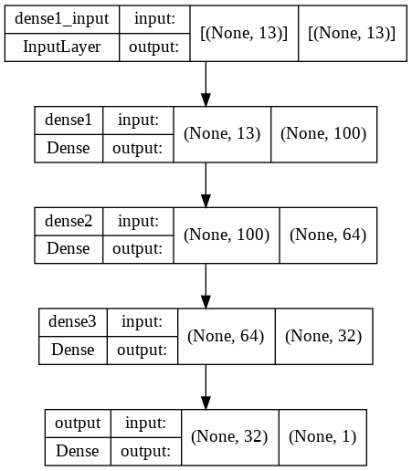

```python
plot_model(model, show_shapes = True)
```

### 모델 컴파일(compile)

- 회귀 문제에서는 주로 평균제곱오차(MSE, Mean Squared Error)를 손실함수로,  
  평균절대오차(MAE, Mean Absolute Error)를 평가지표로 많이 사용!

```python
model.compile(loss = 'mse',
              optimizer = Adam(learning_rate = 1e-2),
              metrics = ['mae'])
```

### 모델 학습

```python
history = model.fit(x_train, y_train, epochs = 300,
                    validation_data = (x_val, y_val), verbose = False)
```

### 모델 평가

- `evaluate()`

```python
model.evaluate(x_test, y_test)
# loss, mae
```

```
[13.961652755737305, 2.624713659286499]
```

```python
history.history.keys()
```

```
dict_keys(['loss', 'mae', 'val_loss', 'val_mae'])
```

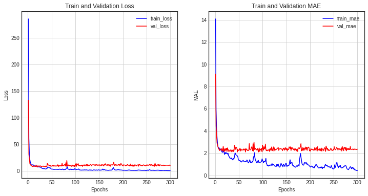

```python
history_dict = history.history

loss = history_dict['loss']
val_loss = history_dict['val_loss']

epochs = range(1, len(loss) + 1)
fig = plt.figure(figsize = (12, 6))

ax1 = fig.add_subplot(1, 2, 1)
ax1.plot(epochs, loss, color = 'blue', label = 'train_loss')
ax1.plot(epochs, val_loss, color = 'red', label = 'val_loss')
ax1.set_title('Train and Validation Loss')
ax1.set_xlabel("Epochs")
ax1.set_ylabel("Loss")
ax1.grid()
ax1.legend()

mae = history_dict['mae']
val_mae = history_dict['val_mae']

ax2 = fig.add_subplot(1, 2, 2)
ax2.plot(epochs, mae, color = 'blue', label = 'train_mae')
ax2.plot(epochs, val_mae, color = 'red', label = 'val_mae')
ax2.set_title('Train and Validation MAE')
ax2.set_xlabel("Epochs")
ax2.set_ylabel("MAE")
ax2.grid()
ax2.legend()
```

### K-Fold 교차 검증

- 데이터셋의 크기가 매우 작은 경우에  
  [훈련, 검증, 테스트] 데이터로 나누게 되면 과소적합이 일어날 확률이 높음
- 이를 해결하기 위해 K-Fold 교차 검증 실행

[figure not shown]

  <sub>출처: https://scikit-learn.org/stable/modules/cross_validation.html</sub>

### 모델 재구성

```python
from tensorflow.keras.layers import Input
from tensorflow.keras.models import Model
from sklearn.model_selection import KFold
```

```python
tf.random.set_seed(123)

(x_train_full, y_train_full), (x_test, y_test) = load_data(path = 'boston_housing.npz',
                                                           test_split = 0.2,
                                                           seed = 123)

mean = np.mean(x_train_full, axis = 0)
std = np.std(x_train_full, axis = 0)

x_train_preprocessed = (x_train_full - mean) / std
x_test = (x_test - mean) / std
```

```python
k = 3

kfold = KFold(n_splits= 3, random_state = 111, shuffle = True)
```

```python
def build_model() :
  input = Input(shape = (13,), name = 'input')
  hidden1 = Dense(100, activation = 'relu', name = 'dense1')(input)
  hidden2 = Dense(64, activation = 'relu', name = 'dense2')(hidden1)
  hidden3 = Dense(32, activation = 'relu', name = 'dense3')(hidden2)
  output = Dense(1, name = 'output')(hidden3)

  model = Model(inputs = [input], outputs = output)

  model.compile(loss = 'mse',
                optimizer = Adam(learning_rate=1e-2),
                metrics = ['mae'])

  return model
```

```python
mse_list = []
mae_list = []
```

```python
for train_idx, val_idx in kfold.split(x_train_full):
  x_train_fold, x_val_fold = x_train_full[train_idx], x_train_full[val_idx]
  y_train_fold, y_val_fold = y_train_full[train_idx], y_train_full[val_idx]

  model = build_model()

  model.fit(x_train_fold, y_train_fold, epochs = 300,
            validation_data = (x_val_fold, y_val_fold), verbose = False)

  test_mse, test_mae = model.evaluate(x_test, y_test)
  mse_list.append(test_mse)
  mae_list.append(test_mae)
```

```python
mse_list, mae_list
```

```
([485.060791015625, 444.59027099609375, 487.9551086425781],
 [20.588518142700195, 19.57476806640625, 20.301403045654297])
```

```python
np.mean(mse_list), np.mean(mae_list),
```

```
(472.53539021809894, 20.154896418253582)
```

# 03.02 케라스 자동차 연비 예측 모델

- Source : https://www.tensorflow.org/tutorials/keras/regression

### modules import

```python
import pandas as pd
import seaborn as sns
import matplotlib.pyplot as plt

import tensorflow as tf
from tensorflow.keras.layers import Dense, Input
from tensorflow.keras.optimizers import RMSprop
from tensorflow.keras.models import Model
from tensorflow.keras.utils import get_file, plot_model
```

```python
sns.set(style = 'white')
plt.style.use('seaborn-white')
```

### 데이터 로드

```python
dataset_path = get_file("auto-mpg.data", "http://archive.ics.uci.edu/ml/machine-learning-databases/auto-mpg/auto-mpg.data")
dataset_path
```

```
'/root/.keras/datasets/auto-mpg.data'
```

```python
column_names = ['MPG', 'Cylinders', 'Displacement', 'Horsepower', 'Weight', 'Acceleration', 'Model Year', 'Origin']
```

```python
raw_dataset = pd.read_csv(dataset_path, names = column_names, na_values = '?',
                          comment = '\t', sep = " ", skipinitialspace = True)
```

```python
dataset = raw_dataset.copy()
dataset.head()
```

|  | MPG | Cylinders | Displacement | Horsepower | Weight | Acceleration | Model Year | Origin |
| --- | --- | --- | --- | --- | --- | --- | --- | --- |
| 0 | 18.0 | 8 | 307.0 | 130.0 | 3504.0 | 12.0 | 70 | 1 |
| 1 | 15.0 | 8 | 350.0 | 165.0 | 3693.0 | 11.5 | 70 | 1 |
| 2 | 18.0 | 8 | 318.0 | 150.0 | 3436.0 | 11.0 | 70 | 1 |
| 3 | 16.0 | 8 | 304.0 | 150.0 | 3433.0 | 12.0 | 70 | 1 |
| 4 | 17.0 | 8 | 302.0 | 140.0 | 3449.0 | 10.5 | 70 | 1 |

```python
dataset.shape
```

```
(398, 8)
```

### 데이터 전처리

```python
dataset.isna().sum() # 결측치 확인
```

```
MPG             0
Cylinders       0
Displacement    0
Horsepower      6
Weight          0
Acceleration    0
Model Year      0
Origin          0
dtype: int64
```

- 해당 데이터는 일부 데이터가 누락되어 있음

```python
dataset = dataset.dropna() # 결측치 제거
```

- "Origin" 범주형 데이터
  - 원-핫 인코딩(one-hot encoding) 진행

```python
dataset["Origin"].unique() # Origin변수의 범주 수
```

```
array([1, 3, 2])
```

```python
origin = dataset.pop("Origin") # Origin열을 추출, 제거
```

```python
# 가변수 생성 (원-핫)
dataset["USA"] = (origin == 1) * 1.0
dataset["Europe"] = (origin == 2) * 1.0
dataset["Japan"] = (origin == 3) * 1.0
dataset.head()
```

|  | MPG | Cylinders | Displacement | Horsepower | Weight | Acceleration | Model Year | USA | Europe | Japan |
| --- | --- | --- | --- | --- | --- | --- | --- | --- | --- | --- |
| 0 | 18.0 | 8 | 307.0 | 130.0 | 3504.0 | 12.0 | 70 | 1.0 | 0.0 | 0.0 |
| 1 | 15.0 | 8 | 350.0 | 165.0 | 3693.0 | 11.5 | 70 | 1.0 | 0.0 | 0.0 |
| 2 | 18.0 | 8 | 318.0 | 150.0 | 3436.0 | 11.0 | 70 | 1.0 | 0.0 | 0.0 |
| 3 | 16.0 | 8 | 304.0 | 150.0 | 3433.0 | 12.0 | 70 | 1.0 | 0.0 | 0.0 |
| 4 | 17.0 | 8 | 302.0 | 140.0 | 3449.0 | 10.5 | 70 | 1.0 | 0.0 | 0.0 |

#### 검증 데이터셋 생성

```python
train_dataset = dataset.sample(frac = 0.8, random_state = 0) # 80%의 데이터를 훈련 데이터로 선택
test_dataset = dataset.drop(train_dataset.index)
```

#### 데이터 조사

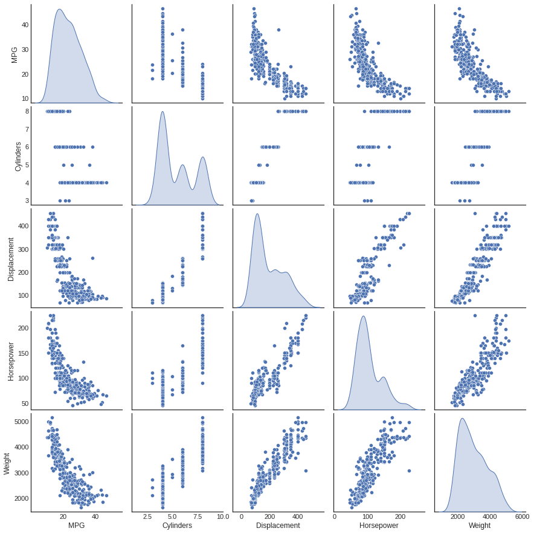

```python
# 산점도
sns.pairplot(train_dataset[["MPG", "Cylinders", "Displacement", "Horsepower", "Weight"]], diag_kind = 'kde');
```

```python
train_stats = train_dataset.describe()
train_stats.pop("MPG")
train_stats = train_stats.transpose()
train_stats
```

|  | count | mean | std | min | 25% | 50% | 75% | max |
| --- | --- | --- | --- | --- | --- | --- | --- | --- |
| Cylinders | 314.0 | 5.477707 | 1.699788 | 3.0 | 4.00 | 4.0 | 8.00 | 8.0 |
| Displacement | 314.0 | 195.318471 | 104.331589 | 68.0 | 105.50 | 151.0 | 265.75 | 455.0 |
| Horsepower | 314.0 | 104.869427 | 38.096214 | 46.0 | 76.25 | 94.5 | 128.00 | 225.0 |
| Weight | 314.0 | 2990.251592 | 843.898596 | 1649.0 | 2256.50 | 2822.5 | 3608.00 | 5140.0 |
| Acceleration | 314.0 | 15.559236 | 2.789230 | 8.0 | 13.80 | 15.5 | 17.20 | 24.8 |
| Model Year | 314.0 | 75.898089 | 3.675642 | 70.0 | 73.00 | 76.0 | 79.00 | 82.0 |
| USA | 314.0 | 0.624204 | 0.485101 | 0.0 | 0.00 | 1.0 | 1.00 | 1.0 |
| Europe | 314.0 | 0.178344 | 0.383413 | 0.0 | 0.00 | 0.0 | 0.00 | 1.0 |
| Japan | 314.0 | 0.197452 | 0.398712 | 0.0 | 0.00 | 0.0 | 0.00 | 1.0 |

#### 데이터의 특성과 레이블 분리

```python
# MPG변수가 반응변수, 따라서 설명변수들과 분리
train_labels = train_dataset.pop("MPG")
test_labels = test_dataset.pop("MPG")
```

#### 데이터 정규화

```python
def normalization(x) :
  return (x - train_stats['mean']) / train_stats['std']

normed_train_data = normalization(train_dataset)
normed_test_data = normalization(test_dataset)
```

```python
train_dataset.keys()
```

```
Index(['Cylinders', 'Displacement', 'Horsepower', 'Weight', 'Acceleration',
       'Model Year', 'USA', 'Europe', 'Japan'],
      dtype='object')
```

### 모델 구성

```python
def build_model() :
  input = Input(shape = (len(train_dataset.keys())), name = 'input')
  hidden1 = Dense(64, activation = 'relu', name = 'dense1')(input)
  hidden2 = Dense(32, activation = 'relu', name = 'dense2')(hidden1)
  output = Dense(1, name = 'output')(hidden2)

  model = Model(inputs = [input],outputs = output)

  model.compile(loss = 'mse',
                optimizer = RMSprop(0.001),
                metrics = ['mae', 'mse'])

  return model
```

```python
model = build_model()
model.summary()
```

```
Model: "model_2"
_________________________________________________________________
 Layer (type)                Output Shape              Param #
=================================================================
 input (InputLayer)          [(None, 9)]               0

 dense1 (Dense)              (None, 64)                640

 dense2 (Dense)              (None, 32)                2080

 output (Dense)              (None, 1)                 33

=================================================================
Total params: 2,753
Trainable params: 2,753
Non-trainable params: 0
_________________________________________________________________
```

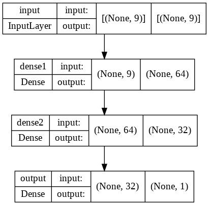

```python
plot_model(model, show_shapes = True)
```

### 샘플 데이터 확인

```python
sample_batch = normed_train_data[:10]
sample_result = model.predict(sample_batch)
sample_batch
```

|  | Cylinders | Displacement | Horsepower | Weight | Acceleration | Model Year | USA | Europe | Japan |
| --- | --- | --- | --- | --- | --- | --- | --- | --- | --- |
| 146 | -0.869348 | -1.009459 | -0.784052 | -1.025303 | -0.379759 | -0.516397 | 0.774676 | -0.465148 | -0.495225 |
| 282 | -0.869348 | -0.530218 | -0.442811 | -0.118796 | 0.624102 | 0.843910 | 0.774676 | -0.465148 | -0.495225 |
| 69 | 1.483887 | 1.482595 | 1.447140 | 1.736877 | -0.738281 | -1.060519 | 0.774676 | -0.465148 | -0.495225 |
| 378 | -0.869348 | -0.865687 | -1.099044 | -1.025303 | -0.308055 | 1.660094 | 0.774676 | -0.465148 | -0.495225 |
| 331 | -0.869348 | -0.942365 | -0.994047 | -1.001603 | 0.875068 | 1.115971 | -1.286751 | -0.465148 | 2.012852 |
| 257 | 0.307270 | 0.351586 | -0.390312 | 0.260397 | 0.588250 | 0.571849 | 0.774676 | -0.465148 | -0.495225 |
| 310 | -0.869348 | -1.019044 | -1.177792 | -1.211344 | 1.161885 | 1.115971 | -1.286751 | -0.465148 | 2.012852 |
| 328 | -0.869348 | -0.472709 | -0.994047 | 0.307796 | 2.237451 | 1.115971 | -1.286751 | 2.143005 | -0.495225 |
| 125 | 0.307270 | 0.025702 | -0.259066 | 0.132419 | 0.337285 | -0.516397 | 0.774676 | -0.465148 | -0.495225 |
| 108 | -0.869348 | -0.942365 | -0.442811 | -0.842816 | 1.233589 | -0.788458 | -1.286751 | -0.465148 | 2.012852 |

### 모델 학습

```python
epochs = 1000

history = model.fit(normed_train_data, train_labels,
                    epochs = epochs, validation_split = 0.2, verbose = False)
```

### 모델 학습 시각화

```python
history.history.keys()
```

```
dict_keys(['loss', 'mae', 'mse', 'val_loss', 'val_mae', 'val_mse'])
```

```python
hist = pd.DataFrame(history.history)
hist['epoch'] = history.epoch
hist.head()
```

|  | loss | mae | mse | val_loss | val_mae | val_mse | epoch |
| --- | --- | --- | --- | --- | --- | --- | --- |
| 0 | 590.736938 | 23.144669 | 590.736938 | 588.520203 | 23.090549 | 588.520203 | 0 |
| 1 | 549.924377 | 22.271559 | 549.924377 | 551.324524 | 22.288853 | 551.324524 | 1 |
| 2 | 516.725586 | 21.538095 | 516.725586 | 515.175354 | 21.495865 | 515.175354 | 2 |
| 3 | 482.990906 | 20.786940 | 482.990906 | 476.570129 | 20.622520 | 476.570129 | 3 |
| 4 | 447.199158 | 19.949387 | 447.199158 | 436.794830 | 19.671116 | 436.794830 | 4 |

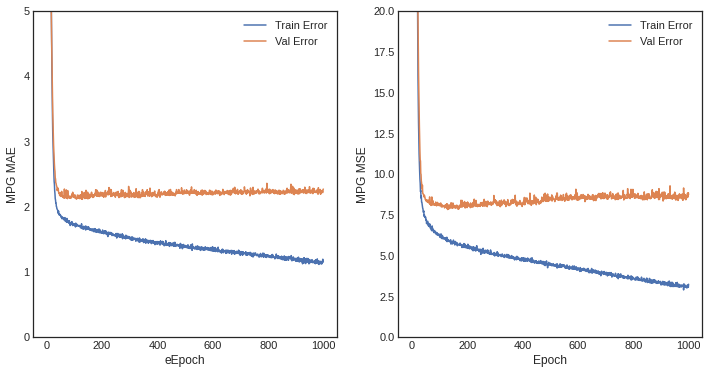

```python
def plot_history(history) :
  hist = pd.DataFrame(history.history)
  hist['epoch'] = history.epoch

  plt.figure(figsize = (12, 6))

  plt.subplot(1, 2, 1)
  plt.xlabel('eEpoch')
  plt.ylabel('MPG MAE')
  plt.plot(hist['epoch'], hist['mae'], label = 'Train Error')
  plt.plot(hist['epoch'], hist['val_mae'], label = 'Val Error')
  plt.ylim([0, 5])
  plt.legend()

  plt.subplot(1, 2, 2)
  plt.xlabel('Epoch')
  plt.ylabel('MPG MSE')
  plt.plot(hist['epoch'], hist['mse'], label = 'Train Error')
  plt.plot(hist['epoch'], hist['val_mse'], label = 'Val Error')
  plt.ylim([0, 20])
  plt.legend()

  plt.show()

plot_history(history)
```

### EarlyStopping을 이용한 규제화

```python
from tensorflow.keras.models import load_model
from tensorflow.keras.callbacks import ModelCheckpoint, EarlyStopping, LearningRateScheduler, TensorBoard
```

```python
model = build_model()

early_stop = EarlyStopping(patience = 10, monitor = 'val_loss',
                                  restore_best_weights = True)

epochs = 1000

history = model.fit(normed_train_data, train_labels,
                    epochs = epochs, validation_split = 0.2, callbacks = [early_stop],
                    verbose = False)
```

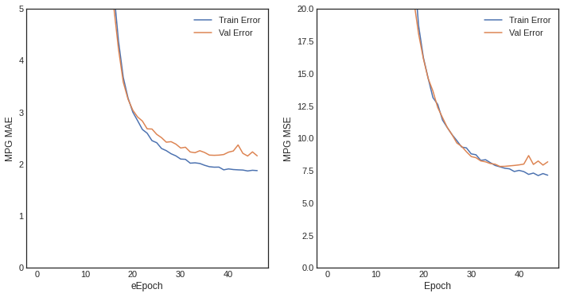

```python
plot_history(history)
```

### 모델 평가

```python
model.evaluate(normed_test_data, test_labels, verbose = False)
# loss, mae, mse
```

```
[5.867674350738525, 1.8463592529296875, 5.867673873901367]
```

### 학습된 모델을 통한 예측

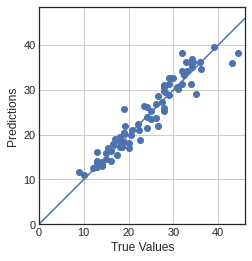

```python
test_pred = model.predict(normed_test_data).flatten()

plt.scatter(test_labels, test_pred)
plt.xlabel('True Values')
plt.ylabel('Predictions')
plt.axis('equal')
plt.axis('square')
plt.grid()
plt.xlim([0, plt.xlim()[1]])
plt.ylim([0, plt.ylim()[1]])
plt.plot([-100, 100], [-100, 100])
```

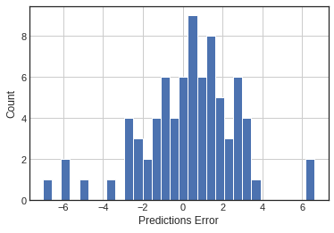

```python
error = test_pred - test_labels
plt.hist(error, bins = 30)
plt.xlabel("Predictions Error")
plt.ylabel("Prediction Error")
plt.grid()
plt.ylabel("Count")
plt.show()
```

# 03.03 케라스 Fashion MNIST 모델

[figure not shown]

<sub>출처: https://www.tensorflow.org/tutorials/keras/classification?hl=ko</sub>

### modules import

```python
import tensorflow as tf
from tensorflow.keras.datasets.fashion_mnist import load_data
from tensorflow.keras.models import Sequential, Model
from tensorflow.keras import models
from tensorflow.keras.layers import Dense, Input
from tensorflow.keras.optimizers import RMSprop
from tensorflow.keras.utils import plot_model

from sklearn.model_selection import train_test_split

import numpy as np
import matplotlib.pyplot as plt
plt.style.use('seaborn-white')
```

### 데이터셋 로드

```python
tf.random.set_seed(111)

(x_train_full, y_train_full), (x_test, y_test) = load_data()

x_train, x_val, y_train, y_val = train_test_split(x_train_full, y_train_full, test_size = 0.3, random_state = 111)
```

### 데이터 확인

```python
x_train.shape, x_val.shape, x_test.shape
```

```
((42000, 28, 28), (18000, 28, 28), (10000, 28, 28))
```

```python
class_names = ['T-shirt/top', 'Trouser', 'Pullover', 'Dress', 'Coat',
               'Sandal', 'Shirt', 'Sneaker', 'Bag', 'Ankle boot']
```

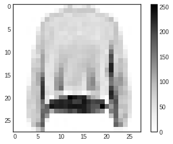

```python
plt.figure()
plt.imshow(x_train[0])
plt.colorbar()
plt.show()
```

### 데이터 전처리

- Normalization
- flatten
- loss='sparse_categorical_crossentropy'

```python
# 색은 0 ~ 255 사이의 값으로 표현
x_train = (x_train.reshape(-1, 28 * 28)) / 255
x_val = (x_val.reshape(-1, 28 * 28)) / 255
x_test = (x_test.reshape(-1, 28 * 28)) / 255
```

```python
y_train = to_categorical(y_train)
y_val = to_categorical(y_val)
y_test = to_categorical(y_test)
```

### 모델 구성 (함수형 API)

```python
input = Input(shape = (784, ), name = "input")
hidden1 = Dense(256, activation = 'relu', name = 'hidden1')(input)
hidden2 = Dense(128, activation = 'relu', name = 'hidden2')(hidden1)
hidden3 = Dense(64, activation = 'relu', name = 'hidden3')(hidden2)
hidden4 = Dense(32, activation = 'relu', name = 'hidden4')(hidden3)
output = Dense(10, activation = 'softmax', name = 'output')(hidden4)

model = Model(inputs = [input], outputs = output)
```

```python
model.summary()
```

```
Model: "model_4"
_________________________________________________________________
 Layer (type)                Output Shape              Param #
=================================================================
 input (InputLayer)          [(None, 784)]             0

 hidden1 (Dense)             (None, 256)               200960

 hidden2 (Dense)             (None, 128)               32896

 hidden3 (Dense)             (None, 64)                8256

 hidden4 (Dense)             (None, 32)                2080

 output (Dense)              (None, 10)                330

=================================================================
Total params: 244,522
Trainable params: 244,522
Non-trainable params: 0
_________________________________________________________________
```

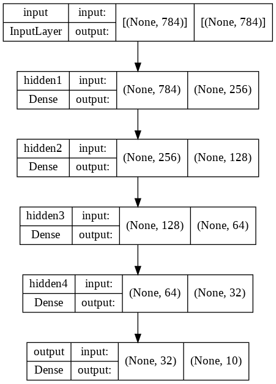

```python
plot_model(model, show_shapes = True)
```

### 모델 컴파일

```python
model.compile(loss = 'sparse_categorical_crossentropy',
              optimizer = RMSprop(0.01),
              metrics=['accuracy'])
```

### 모델 학습

- 모델 시각화를 위해 history라는 변수에 학습 과정을 담음

```python
history = model.fit(x_train, y_train, epochs = 10,
                    batch_size = 128,
                    validation_data = (x_val, y_val), verbose = False)
```

### 학습 결과 시각화

```python
history_dict = history.history
loss = history_dict['loss']
val_loss = history_dict['val_loss']
accuracy = history_dict['accuracy']
val_accuracy = history_dict['val_accuracy']
```

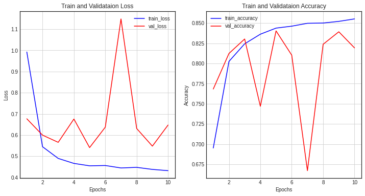

```python
epochs = range(1, len(loss) + 1)
fig = plt.figure(figsize = (12, 6))

ax1 = fig.add_subplot(1, 2, 1)
ax1.plot(epochs, loss, color = 'blue', label = 'train_loss')
ax1.plot(epochs, val_loss, color = 'red', label = 'val_loss')
ax1.set_title('Train and Validataion Loss')
ax1.set_xlabel('Epochs')
ax1.set_ylabel('Loss')
ax1.grid()
ax1.legend()

ax2 = fig.add_subplot(1, 2, 2)
ax2.plot(epochs, accuracy, color = 'blue', label = 'train_accuracy')
ax2.plot(epochs, val_accuracy, color = 'red', label = 'val_accuracy')
ax2.set_title('Train and Validataion Accuracy')
ax2.set_xlabel('Epochs')
ax2.set_ylabel('Accuracy')
ax2.grid()
ax2.legend()
plt.show()
```

### 다른 옵티마이저로 실행

- 아래의 과정 다시 실행
  - 데이터셋 로드
  - 데이터 전처리
  - 모델 구성

```python
from tensorflow.keras.optimizers import SGD
```

```python
model.compile(loss = 'sparse_categorical_crossentropy',
              optimizer = SGD(0.01),
              metrics = ['accuracy'])
```

```python
history2 = model.fit(x_train, y_train, epochs = 10,
                    batch_size = 128,
                    validation_data = (x_val, y_val), verbose = False)
```

```python
history2_dict = history2.history
loss = history2_dict['loss']
val_loss = history2_dict['val_loss']
accuracy = history2_dict['accuracy']
val_accuracy = history2_dict['val_accuracy']
```

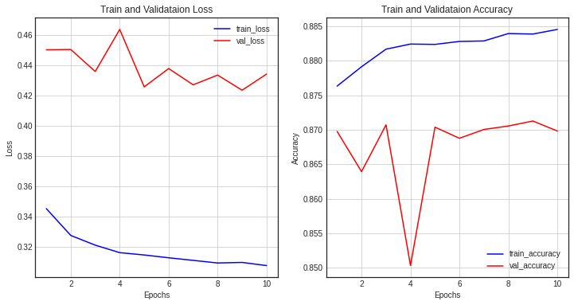

```python
epochs = range(1, len(loss) + 1)
fig = plt.figure(figsize = (12, 6))

ax1 = fig.add_subplot(1, 2, 1)
ax1.plot(epochs, loss, color = 'blue', label = 'train_loss')
ax1.plot(epochs, val_loss, color = 'red', label = 'val_loss')
ax1.set_title('Train and Validataion Loss')
ax1.set_xlabel('Epochs')
ax1.set_ylabel('Loss')
ax1.grid()
ax1.legend()

ax2 = fig.add_subplot(1, 2, 2)
ax2.plot(epochs, accuracy, color = 'blue', label = 'train_accuracy')
ax2.plot(epochs, val_accuracy, color = 'red', label = 'val_accuracy')
ax2.set_title('Train and Validataion Accuracy')
ax2.set_xlabel('Epochs')
ax2.set_ylabel('Accuracy')
ax2.grid()
ax2.legend()
plt.show()
```

### 모델 평가 (1)

- optimizer: SGD()로 학습한 모델
- evaluate

```python
model.evaluate(x_test, y_test)
# loss, accuracy
```

```
[0.5095711350440979, 0.8608999848365784]
```

### 학습된 모델을 통해 값 예측

```python
pred_ys = model.predict(x_test)
print(pred_ys.shape)
print(pred_ys[0])
```

```
(10000, 10)
[8.5232790e-18 2.9257264e-23 8.2036541e-22 5.1235511e-26 1.9247250e-18
 3.6050843e-03 4.2762898e-16 7.2216645e-02 3.6837182e-14 9.2417824e-01]
```

```python
arg_pred_y = np.argmax(pred_ys, axis = 1)
print(class_names[y_test[0]]) # 실제값의 범주
print(class_names[arg_pred_y[0]]) # 예측값의 범주
```

```
Ankle boot
Ankle boot
```

### 모델 평가(2)

- optimizer: SGD()로 설정한 모델
- 혼동 행렬 (Confusion Matrix)

```python
from sklearn.metrics import classification_report, confusion_matrix
import seaborn as sns
sns.set(style = 'white')

from tensorflow.keras.utils import to_categorical
```

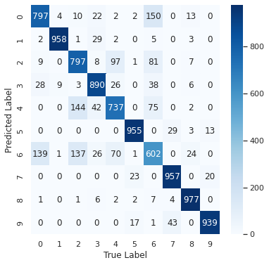

```python
plt.figure(figsize = (6, 6))
cm = confusion_matrix(np.argmax(y_test, axis = -1), np.argmax(pred_ys, axis = -1))
sns.heatmap(cm, annot = True, fmt = 'd', cmap = 'Blues')
plt.xlabel('True Label')
plt.ylabel('Predicted Label')
plt.show()
```

### 모델 평가 (3)

- optimizer: SGD()로 설정한 모델
- 분류 보고서

```python
from sklearn.metrics import classification_report

print(classification_report(np.argmax(y_test, axis = -1), np.argmax(pred_ys, axis = -1)))
```

```
              precision    recall  f1-score   support

           0       0.82      0.80      0.81      1000
           1       0.99      0.96      0.97      1000
           2       0.73      0.80      0.76      1000
           3       0.87      0.89      0.88      1000
           4       0.79      0.74      0.76      1000
           5       0.95      0.95      0.95      1000
           6       0.63      0.60      0.61      1000
           7       0.93      0.96      0.94      1000
           8       0.94      0.98      0.96      1000
           9       0.97      0.94      0.95      1000

    accuracy                           0.86     10000
   macro avg       0.86      0.86      0.86     10000
weighted avg       0.86      0.86      0.86     10000
```

# 04 케라스 다양한 학습 기술

- 과대적합, 과소적합을 막기 위한 방법들
  - 모델의 크기 축소
  - 초기화
  - 옵티마이저
  - 배치 정규화
  - 규제화

### 모델의 크기 축소

- 가장 단순한 방법
- 모델의 크기를 줄인다는 것은 **학습 파라미터의 수를 줄이는 것**

#### 데이터 준비

- 설명을 위한 코드

```python
from tensorflow.keras.datasets import imdb
import numpy as np
from tensorflow.keras.utils import plot_model

(train_data, train_labels), (test_data,test_labels) = imdb.load_data(num_words = 10000)
```

```python
train_data.shape, test_data.shape
```

```
((25000,), (25000,))
```

```python
len(train_data[0])
```

```
218
```

```python
def vectorize_seq(seqs, dim = 10000) :
  results = np.zeros((len(seqs), dim))
  for i, seq in enumerate(seqs):
    results[i, seq] = 1

  return results

# 25000 X 10000 행렬
# n번째 데이터가 m단어를 가지고 있다면 n행 m열을 1로
x_train = vectorize_seq(train_data)
x_test = vectorize_seq(test_data)
y_train = np.asarray(train_labels).astype('float32')
y_test = np.asarray(test_labels).astype('float32')
```

```python
x_train.shape
```

```
(25000, 10000)
```

#### 2가지의 모델 설정

```python
import tensorflow as tf
from tensorflow.keras.models import Sequential
from tensorflow.keras.layers import Dense, Input
```

```python
model_1 = Sequential([Dense(16, activation = 'relu', input_shape = (10000,), name = 'input'),
                      Dense(16, activation = 'relu', name = 'hidden'),
                      Dense(1, activation = 'sigmoid', name = 'output')])
```

```python
model_1.summary()
```

```
Model: "sequential"
_________________________________________________________________
 Layer (type)                Output Shape              Param #
=================================================================
 input (Dense)               (None, 16)                160016

 hidden (Dense)              (None, 16)                272

 output (Dense)              (None, 1)                 17

=================================================================
Total params: 160,305
Trainable params: 160,305
Non-trainable params: 0
_________________________________________________________________
```

```python
model_2 = Sequential([Dense(7, activation = 'relu', input_shape = (10000,), name = 'input2'),
                      Dense(7, activation = 'relu', name = 'hidden2'),
                      Dense(1, activation = 'sigmoid', name = 'output2')])
```

```python
model_2.summary()
```

```
Model: "sequential_1"
_________________________________________________________________
 Layer (type)                Output Shape              Param #
=================================================================
 input2 (Dense)              (None, 7)                 70007

 hidden2 (Dense)             (None, 7)                 56

 output2 (Dense)             (None, 1)                 8

=================================================================
Total params: 70,071
Trainable params: 70,071
Non-trainable params: 0
_________________________________________________________________
```

```python
model_1.compile(loss = 'binary_crossentropy',
                optimizer = 'rmsprop',
                metrics = ['acc'])

model_2.compile(loss = 'binary_crossentropy',
                optimizer = 'rmsprop',
                metrics = ['acc'])
```

#### 2개의 모델 학습

```python
model_1_hist = model_1.fit(x_train, y_train, epochs = 20,
                           batch_size = 512, validation_data = (x_test, y_test), verbose = False)
```

```python
model_2_hist = model_1.fit(x_train, y_train, epochs = 20,
                           batch_size = 512, validation_data = (x_test, y_test), verbose = False)
```

#### 비교

```python
epochs = range(1, 21)
model_1_val_loss = model_1_hist.history['val_loss']
model_2_val_loss = model_2_hist.history['val_loss']
```

```python
import matplotlib.pyplot as plt
plt.style.use('seaborn-white')
```

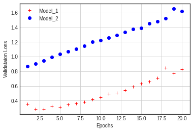

```python
plt.plot(epochs, model_1_val_loss, 'r+', label = 'Model_1')
plt.plot(epochs, model_2_val_loss, 'bo', label = 'Model_2')
plt.xlabel('Epochs')
plt.ylabel('Validataion Loss')
plt.legend()
plt.grid()
plt.show()
```

### 모델의 크기 축소 (2)

#### 모델 구성

```python
model_3 = Sequential([Dense(1024, activation = 'relu', input_shape = (10000,), name = 'input3'),
                      Dense(1024, activation = 'relu', name = 'hidden3'),
                      Dense(1, activation = 'sigmoid', name = 'output3')])

model_3.compile(loss = 'binary_crossentropy',
                optimizer = 'rmsprop',
                metrics = ['acc'])

model_3.summary()
```

```
Model: "sequential_2"
_________________________________________________________________
 Layer (type)                Output Shape              Param #
=================================================================
 input3 (Dense)              (None, 1024)              10241024

 hidden3 (Dense)             (None, 1024)              1049600

 output3 (Dense)             (None, 1)                 1025

=================================================================
Total params: 11,291,649
Trainable params: 11,291,649
Non-trainable params: 0
_________________________________________________________________
```

#### 모델 학습

- 시간 소요

```python
model_3_hist = model_3.fit(x_train, y_train, epochs = 20,
                           batch_size = 512, validation_data = (x_test, y_test), verbose = False)
```

#### 시각화

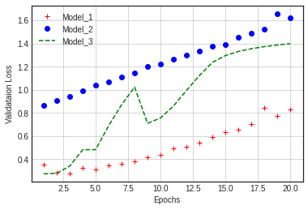

```python
model_3_val_loss = model_3_hist.history['val_loss']

plt.plot(epochs, model_1_val_loss, 'r+', label = 'Model_1')
plt.plot(epochs, model_2_val_loss, 'bo', label = 'Model_2')
plt.plot(epochs, model_3_val_loss, 'g--', label = 'Model_3')
plt.xlabel('Epochs')
plt.ylabel('Validataion Loss')
plt.legend()
plt.grid()
plt.show()
```

- 볼륨이 큰 신경망일수록 빠르게 훈련데이터 모델링 가능(학습 손실이 낮아짐)
- 과대 적합에는 더욱 민감해짐
- 이는 학습-검증 데이터의 손실을 보면 알 수 있음

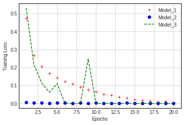

```python
model_1_train_loss = model_1_hist.history['loss']
model_2_train_loss = model_2_hist.history['loss']
model_3_train_loss = model_3_hist.history['loss']

plt.plot(epochs, model_1_train_loss, 'r+', label = 'Model_1')
plt.plot(epochs, model_2_train_loss, 'bo', label = 'Model_2')
plt.plot(epochs, model_3_train_loss, 'g--', label = 'Model_3')
plt.xlabel('Epochs')
plt.ylabel('Training Loss')
plt.legend()
plt.grid()
plt.show()
```

### 가중치 초기화

#### 초기화 전략

- Glorot Initialization (Xavier)
  - 활성화 함수
    - 없음
    - tanh
    - sigmoid
    - softmax
- He Initialization
  - 활성화 함수
    - ReLU
    - LeakyReLU
    - ELU 등

```python
from tensorflow.keras.layers import Dense, LeakyReLU, Activation
from tensorflow.keras.models import Sequential
```

```python
model = Sequential([Dense(30, kernel_initializer = 'he_normal', input_shape = [10, 10]),
                    LeakyReLU(alpha = 0.2),
                    Dense(1, kernel_initializer = 'he_normal'),
                    Activation("softmax")])
model.summary()
```

```
Model: "sequential_3"
_________________________________________________________________
 Layer (type)                Output Shape              Param #
=================================================================
 dense (Dense)               (None, 10, 30)            330

 leaky_re_lu (LeakyReLU)     (None, 10, 30)            0

 dense_1 (Dense)             (None, 10, 1)             31

 activation (Activation)     (None, 10, 1)             0

=================================================================
Total params: 361
Trainable params: 361
Non-trainable params: 0
_________________________________________________________________
```

### 고속 옵티마이저

#### 모멘텀 최적화

$ \qquad v \ \leftarrow \ \alpha \ v - \gamma \ \frac{\partial L}{\partial W} \\ \qquad W \ \leftarrow \ W \ + \ v $

- $\alpha\ $ : 관성계수
- $v$ : 속도
- $\gamma\ $ : 학습률
- $\frac{\partial L}{\partial W}\ $ : 손실함수에 대한 미분

```python
import tensorflow as tf
from tensorflow.keras.optimizers import SGD
```

```python
optimizer = SGD(learning_rate = 0.001, momentum = 0.9)
```

#### 네스테로프 (Nesterov)

- 모멘텀의 방향으로 조금 앞선 곳에서 손실함수의 그라디언트를 구함
- 시간이 지날수록 조금 더 빨리 최솟값에 도달

$ \qquad m \ \leftarrow \ \beta m - \eta \bigtriangledown_\theta J(\theta + \beta m) \\ \qquad \theta \ \leftarrow \ \theta \ + m $

[figure not shown]

  <sub>출처: CS231n</sub>

```python
optimizer = SGD(learning_rate = 0.001, momentum = 0.9, nesterov = True)
```

#### AdaGrad

- 보통 간단한 모델에는 효과 좋을 수는 있으나, 심층 신경망 모델에서는 사용 X

$ \qquad h \ \leftarrow \ h + \frac{\partial L}{\partial W} \odot \frac{\partial L}{\partial W} \\ \qquad W \ \leftarrow \ W \ + \gamma \frac{1}{\sqrt h} \ \frac{\partial L}{\partial W} $

- $h\ $ : 기존 기울기를 제곱하여 더한 값
- $\gamma\ $ : 학습률
- $\frac{\partial L}{\partial W}\ $ : $W$에 대한 미분

```python
from tensorflow.keras.optimizers import Adagrad
```

```python
optimizer = Adagrad(learning_rate = 0.001)
```

#### RMSProp

$ \qquad s \ \leftarrow \ \beta \ s + (1 - \beta) \bigtriangledown_{\theta} J(\theta) \otimes \bigtriangledown_{\theta} J(\theta) \\ \qquad \theta \ \leftarrow \ \theta \ - \eta \ \bigtriangledown_{\theta} J(\theta) \oslash \sqrt{s + \epsilon} $

- $s \ $ : 그래디언트의 제곱을 감쇠율을 곱한 후 더함
- $\eta\ $ : 학습률
- $\bigtriangledown_{\theta} J(\theta) \ $ : 손실함수의 미분값

```python
from tensorflow.keras.optimizers import RMSprop
```

```python
optimizer = RMSprop(learning_rate = 0.001, rho = 0.9)
```

#### Adam

$ \qquad m \ \leftarrow \ \beta_1 \ m - (1 - \beta_1)\ \frac{\partial L}{\partial W} \\ \qquad s \ \leftarrow \ \beta_2 \ s + (1 - \beta_2) \frac{\partial L}{\partial W} \odot \frac{\partial L}{\partial W} \\ \qquad \hat{m} \ \leftarrow \frac{m}{1 - \beta_1^t} \\ \qquad \hat{s} \ \leftarrow \frac{s}{1 - \beta_2^t} \\ \qquad W \ \leftarrow \ W \ + \gamma \ \hat{m}\ \oslash \sqrt{\hat{s} + \epsilon} $

- $\beta\ $ : 지수 평균의 업데이트 계수
- $\gamma\ $ : 학습률
- $\beta_1 \approx 0.9\ ,\ \ \beta_2 \approx 0.999$
- $\frac{\partial L}{\partial W}\ $ : $W$에 대한 미분

```python
from tensorflow.keras.optimizers import Adam
```

```python
optimizer = Adam(learning_rate = 0.001, beta_1 = 0.9, beta_2 = 0.999)
```